# Bayesian GLM Part4

Author

Murray Logan

Published

09/09/2025

# 1 Preparations

Load the necessary libraries

```r
library(tidyverse) # for data wrangling etc
library(rstanarm) # for fitting models in STAN
library(cmdstanr) # for cmdstan
library(brms) # for fitting models in STAN
library(coda) # for diagnostics
library(bayesplot) # for diagnostics
library(ggmcmc) # for MCMC diagnostics
library(DHARMa) # for residual diagnostics
library(rstan) # for interfacing with STAN
library(emmeans) # for marginal means etc
library(broom) # for tidying outputs
library(tidybayes) # for more tidying outputs
library(ggeffects) # for partial plots
library(broom.mixed) # for summarising models
library(ggeffects) # for partial effects plots
library(bayestestR) # for ROPE
library(see) # for some plots
library(easystats) # for the easystats ecosystem
library(patchwork) # for multiple plots
library(modelsummary) # for data and model summaries
library(car) # for scatterplot matrices
library(ggridges) # for ridge plots
theme_set(theme_grey()) # put the default ggplot theme back
source("helperFunctions.R")
```

# 2 Scenario

Loyn (1987) modelled the abundance of forest birds with six predictor variables (patch area, distance to nearest patch, distance to nearest larger patch, grazing intensity, altitude and years since the patch had been isolated).

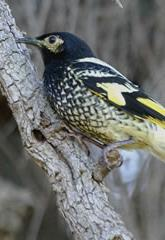

**Figure** 1: Regent honeyeater

**Table** 1: Format of loyn.csv data file

| ABUND | DIST | LDIST | AREA | GRAZE | ALT | YR.ISOL |
| --- | --- | --- | --- | --- | --- | --- |
| .. | .. | .. | .. | .. | .. | .. |

**Table** 2: Description of the variables in the loyn data file

| **ABUND** | Abundance of forest birds in patch- response variable |
| --- | --- |
| **DIST** | Distance to nearest patch - predictor variable |
| **LDIST** | Distance to nearest larger patch - predictor variable |
| **AREA** | Size of the patch - predictor variable |
| **GRAZE** | Grazing intensity (1 to 5, representing light to heavy) - predictor variable |
| **ALT** | Altitude - predictor variable |
| **YR.ISOL** | Number of years since the patch was isolated - predictor variable |

The aim of the analysis is to investigate the effects of a range of predictors on the abundance of forest birds.

# 3 Read in the data

```r
loyn <- read_csv("../data/loyn.csv", trim_ws = TRUE)
```

**glimpse**

```r
loyn |> glimpse()
```

```
Rows: 56
Columns: 7
$ ABUND   <dbl> 5.3, 2.0, 1.5, 17.1, 13.8, 14.1, 3.8, 2.2, 3.3, 3.0, 27.6, 1.8…
$ AREA    <dbl> 0.1, 0.5, 0.5, 1.0, 1.0, 1.0, 1.0, 1.0, 1.0, 1.0, 2.0, 2.0, 2.…
$ YR.ISOL <dbl> 1968, 1920, 1900, 1966, 1918, 1965, 1955, 1920, 1965, 1900, 19…
$ DIST    <dbl> 39, 234, 104, 66, 246, 234, 467, 284, 156, 311, 66, 93, 39, 40…
$ LDIST   <dbl> 39, 234, 311, 66, 246, 285, 467, 1829, 156, 571, 332, 93, 39, …
$ GRAZE   <dbl> 2, 5, 5, 3, 5, 3, 5, 5, 4, 5, 3, 5, 2, 1, 5, 5, 3, 3, 3, 2, 2,…
$ ALT     <dbl> 160, 60, 140, 160, 140, 130, 90, 60, 130, 130, 210, 160, 210, …
```

**str**

```r
loyn |> str()
```

```
spc_tbl_ [56 × 7] (S3: spec_tbl_df/tbl_df/tbl/data.frame)
 $ ABUND  : num [1:56] 5.3 2 1.5 17.1 13.8 14.1 3.8 2.2 3.3 3 ...
 $ AREA   : num [1:56] 0.1 0.5 0.5 1 1 1 1 1 1 1 ...
 $ YR.ISOL: num [1:56] 1968 1920 1900 1966 1918 ...
 $ DIST   : num [1:56] 39 234 104 66 246 234 467 284 156 311 ...
 $ LDIST  : num [1:56] 39 234 311 66 246 ...
 $ GRAZE  : num [1:56] 2 5 5 3 5 3 5 5 4 5 ...
 $ ALT    : num [1:56] 160 60 140 160 140 130 90 60 130 130 ...
 - attr(*, "spec")=
  .. cols(
  ..   ABUND = col_double(),
  ..   AREA = col_double(),
  ..   YR.ISOL = col_double(),
  ..   DIST = col_double(),
  ..   LDIST = col_double(),
  ..   GRAZE = col_double(),
  ..   ALT = col_double()
  .. )
 - attr(*, "problems")=<externalptr>
```

**head**

```r
## Explore the first 6 rows of the data
loyn |> head()
```

```
# A tibble: 6 × 7
  ABUND  AREA YR.ISOL  DIST LDIST GRAZE   ALT
  <dbl> <dbl>   <dbl> <dbl> <dbl> <dbl> <dbl>
1   5.3   0.1    1968    39    39     2   160
2   2     0.5    1920   234   234     5    60
3   1.5   0.5    1900   104   311     5   140
4  17.1   1      1966    66    66     3   160
5  13.8   1      1918   246   246     5   140
6  14.1   1      1965   234   285     3   130
```

**Easystats (datawizard)**

```r
loyn |> datawizard::data_codebook()
```

```
loyn (56 rows and 7 variables, 7 shown)

ID | Name    | Type    | Missings |       Values |          N
---+---------+---------+----------+--------------+-----------
1  | ABUND   | numeric | 0 (0.0%) |  [1.5, 39.6] |         56
---+---------+---------+----------+--------------+-----------
2  | AREA    | numeric | 0 (0.0%) |  [0.1, 1771] |         56
---+---------+---------+----------+--------------+-----------
3  | YR.ISOL | numeric | 0 (0.0%) | [1890, 1976] |         56
---+---------+---------+----------+--------------+-----------
4  | DIST    | numeric | 0 (0.0%) |   [26, 1427] |         56
---+---------+---------+----------+--------------+-----------
5  | LDIST   | numeric | 0 (0.0%) |   [26, 4426] |         56
---+---------+---------+----------+--------------+-----------
6  | GRAZE   | numeric | 0 (0.0%) |            1 | 13 (23.2%)
   |         |         |          |            2 |  8 (14.3%)
   |         |         |          |            3 | 15 (26.8%)
   |         |         |          |            4 |  7 (12.5%)
   |         |         |          |            5 | 13 (23.2%)
---+---------+---------+----------+--------------+-----------
7  | ALT     | numeric | 0 (0.0%) |    [60, 260] |         56
-------------------------------------------------------------
```

**Skim (modelsummary)**

Unique

Missing Pct.

Mean

SD

Min

Median

Max

Histogram

ABUND

54

0

19.5

10.7

1.5

21.0

39.6

[figure not shown]

AREA

36

0

69.3

266.1

0.1

7.5

1771.0

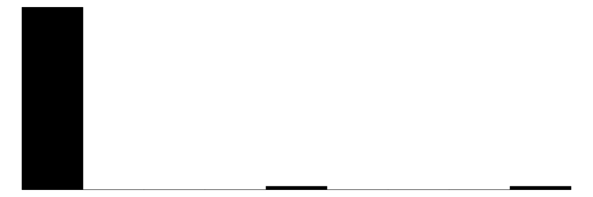

YR.ISOL

25

0

1949.8

25.6

1890.0

1962.5

1976.0

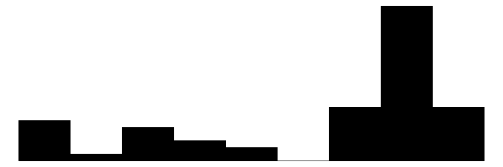

DIST

31

0

240.4

219.1

26.0

234.0

1427.0

[figure not shown]

LDIST

46

0

733.3

916.1

26.0

338.5

4426.0

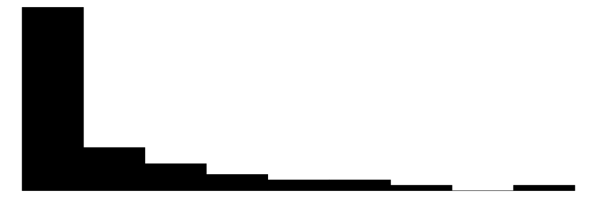

GRAZE

5

0

3.0

1.5

1.0

3.0

5.0

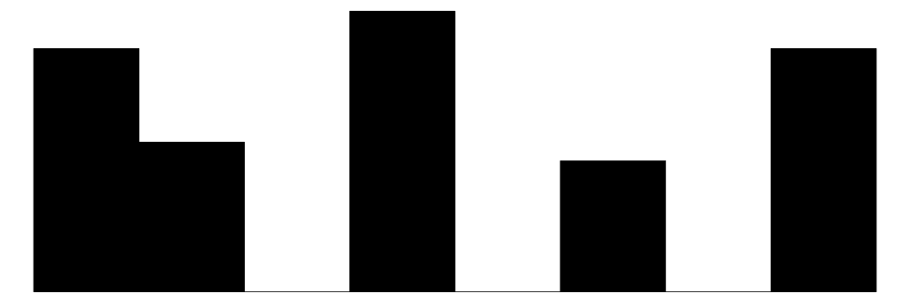

ALT

20

0

146.2

43.5

60.0

140.0

260.0

[figure not shown]

```r
loyn |> modelsummary::datasummary_skim(categorical = TRUE)
```

# 4 Exploratory data analysis

When we explored this analysis from a frequentist perspective, we decided on a log-normal like model. This was a model that was fit against a Gaussian distribution, yet with a log-link. We will replicate that model here in a Bayesian framework.

In the previous exploration of this model, we elected to treat Grazing intensity as a categorical variable - we will again code Grazing intensity as a categorical variable.

```r
loyn <- loyn |> mutate(fGRAZE = factor(GRAZE))
```

Model formula:
$$\begin{align}
y_i &\sim{} \mathcal{N}(\mu_i, \sigma^2)\\
log(\mu_i) &= \boldsymbol{\beta} \bf{X_i}\\
\beta_0 &\sim{} \mathcal{N}(3.4, 0.1)\\
\beta_{1-9} &\sim{} \mathcal{N}(0, 2)\\
\sigma &\sim{} \mathcal{t}(3,0, 1.5)
\end{align}$$

where $\boldsymbol{\beta}$ is a vector of effects parameters and $\bf{X}$ is a model matrix representing the additive effects of the scaled versions of distance (ln), distance to the nearest large patch (ln), patch area (ln), grazing intensity, year of isolation and altitude on the abundance of forest birds.

## 4.1 Scatterplot matrix

To re-acquaint ourselves with the data, I we will revisit the scatterplot matrix that we generated prior to the frequentist analysis.

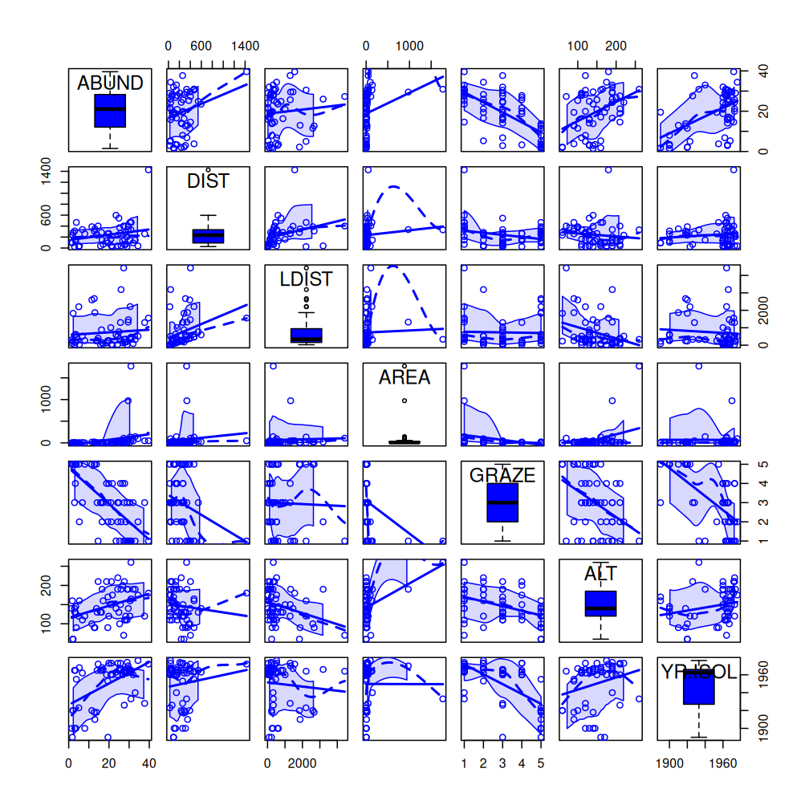

```r
scatterplotMatrix(~ ABUND + DIST + LDIST + AREA + GRAZE + ALT + YR.ISOL,
  data = loyn,
  diagonal = list(method = "boxplot")
)
```

We again notice that DIST, LDIST and AREA are skewed, so we will normalise them via a logarithmic transformation.

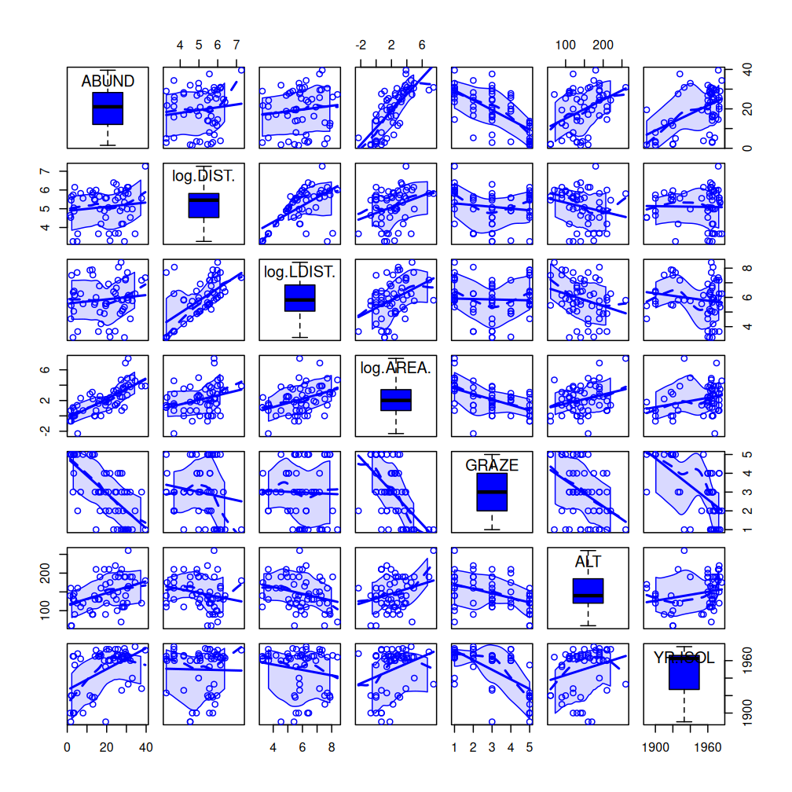

```r
scatterplotMatrix(~ ABUND + log(DIST) + log(LDIST) + log(AREA) + GRAZE + ALT + YR.ISOL,
  data = loyn,
  diagonal = list(method = "boxplot")
)
```

# 5 Fit the model

**frequentist**

```r
loyn_glm <- glm(
  ABUND ~ scale(log(DIST)) + scale(log(LDIST)) + scale(log(AREA)) +
    fGRAZE + scale(ALT) + scale(YR.ISOL),
  data = loyn,
  family = gaussian(link = "log")
)
loyn_glm |> summary()
```

```
Call:
glm(formula = ABUND ~ scale(log(DIST)) + scale(log(LDIST)) +
    scale(log(AREA)) + fGRAZE + scale(ALT) + scale(YR.ISOL),
    family = gaussian(link = "log"), data = loyn)

Coefficients:
                   Estimate Std. Error t value Pr(>|t|)
(Intercept)        3.092248   0.112856  27.400  < 2e-16 ***
scale(log(DIST))  -0.018067   0.057247  -0.316  0.75373
scale(log(LDIST))  0.057086   0.059984   0.952  0.34623
scale(log(AREA))   0.203976   0.059620   3.421  0.00132 **
fGRAZE2            0.039644   0.148978   0.266  0.79134
fGRAZE3            0.019654   0.137752   0.143  0.88717
fGRAZE4           -0.001197   0.156199  -0.008  0.99392
fGRAZE5           -1.121563   0.343631  -3.264  0.00208 **
scale(ALT)        -0.003237   0.048607  -0.067  0.94719
scale(YR.ISOL)    -0.018246   0.074404  -0.245  0.80737
---
Signif. codes:  0 '***' 0.001 '**' 0.01 '*' 0.05 '.' 0.1 ' ' 1

(Dispersion parameter for gaussian family taken to be 42.40928)

    Null deviance: 6337.9  on 55  degrees of freedom
Residual deviance: 1950.8  on 46  degrees of freedom
AIC: 379.76

Number of Fisher Scoring iterations: 6
```

**rstanarm**

**Using default priors**

In `rstanarm`, the default priors are designed to be weakly informative. They are chosen to provide moderate regularisation (to help prevent over-fitting) and help stabilise the computations.

```r
loyn_rstanarm <- stan_glm(
  ABUND ~ scale(log(DIST)) +
    scale(log(LDIST)) +
    scale(log(AREA)) +
    fGRAZE +
    scale(ALT) +
    scale(YR.ISOL),
  data = loyn,
  family = gaussian(link = "log"),
  iter = 5000, warmup = 2500,
  chains = 3, thin = 5, refresh = 0
)
```

[output not shown]

[output not shown]

```
Warning: Markov chains did not converge! Do not analyze results!
```

**Conclusions:**

```r
loyn_rstanarm <- stan_glm(
  ABUND ~ scale(log(DIST)) +
    scale(log(LDIST)) +
    scale(log(AREA)) +
    fGRAZE +
    scale(ALT) +
    scale(YR.ISOL),
  data = loyn,
  family = gaussian(link = "log"),
  iter = 5000, warmup = 2500,
  chains = 3, thin = 5, refresh = 0,
  adapt_delta = 0.99
)
```

There are still a substantial number of divergent transitions. It is possible that the priors are too vague.

```r
prior_summary(loyn_rstanarm)
```

```
Priors for model 'loyn_rstanarm'
------
Intercept (after predictors centered)
  Specified prior:
    ~ normal(location = 0, scale = 2.5)
  Adjusted prior:
    ~ normal(location = 0, scale = 27)

Coefficients
  Specified prior:
    ~ normal(location = [0,0,0,...], scale = [2.5,2.5,2.5,...])
  Adjusted prior:
    ~ normal(location = [0,0,0,...], scale = [26.84,26.84,26.84,...])

Auxiliary (sigma)
  Specified prior:
    ~ exponential(rate = 1)
  Adjusted prior:
    ~ exponential(rate = 0.093)
------
See help('prior_summary.stanreg') for more details
```

**Conclusions:**

```r
loyn_rstanarm1 <- update(loyn_rstanarm, prior_PD = TRUE)
```

```
Data points may overlap. Use the `jitter` argument to add some amount of
  random variation to the location of data points and avoid overplotting.
```

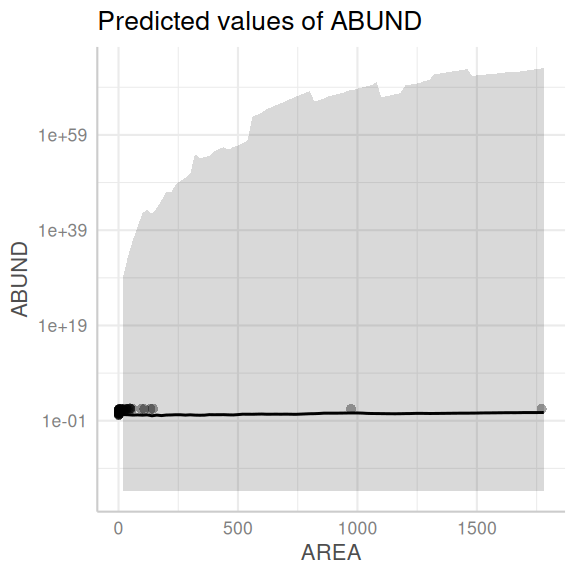

```r
ggemmeans(loyn_rstanarm1, ~AREA) |> plot(show_data = TRUE) + scale_y_log10()
```

[output not shown]

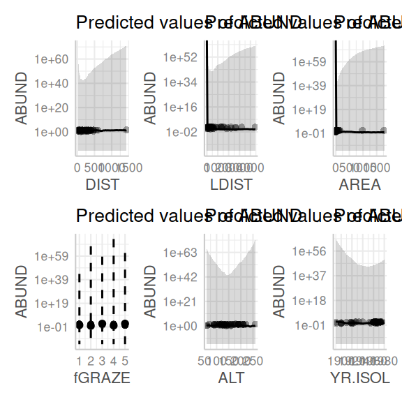

```r
ggpredict(loyn_rstanarm1) |>
  plot(show_data = TRUE) |>
  wrap_plots() &
  scale_y_log10()
```

**Conclusions:**

- we see that the range of predictions are extremely wide and the slope could range from strongly negative to strongly positive.

**Defining priors**

I will also overlay the raw data for comparison.

```r
loyn_rstanarm2 <- stan_glm(
  ABUND ~ scale(log(DIST)) +
    scale(log(LDIST)) +
    scale(log(AREA)) +
    fGRAZE +
    scale(ALT) +
    scale(YR.ISOL),
  data = loyn,
  family = gaussian(link = "log"),
  prior_intercept = normal(3, 1, autoscale = FALSE),
  prior = normal(0, 1, autoscale = FALSE),
  prior_aux = cauchy(0, 2),
  prior_PD = TRUE,
  iter = 5000, thin = 5,
  chains = 3, warmup = 2500,
  refresh = 0
)
```

**Conclusions:**

- there are no longer any warning messages.

```
Data points may overlap. Use the `jitter` argument to add some amount of
  random variation to the location of data points and avoid overplotting.
```

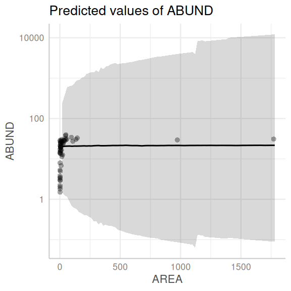

```r
ggemmeans(loyn_rstanarm2, ~AREA) |>
  plot(show_data = TRUE) + scale_y_log10()
```

[output not shown]

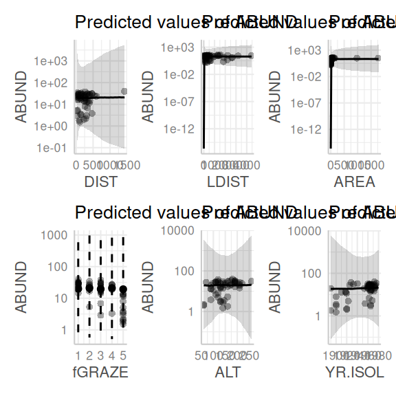

```r
ggpredict(loyn_rstanarm2) |>
  plot(show_data = TRUE) |>
  wrap_plots() &
  scale_y_log10()
```

Now lets refit, conditioning on the data.

```r
loyn_rstanarm3 <- update(loyn_rstanarm2, prior_PD = FALSE)
```

**Plotting prior and posterior**

```
Drawing from prior...
```

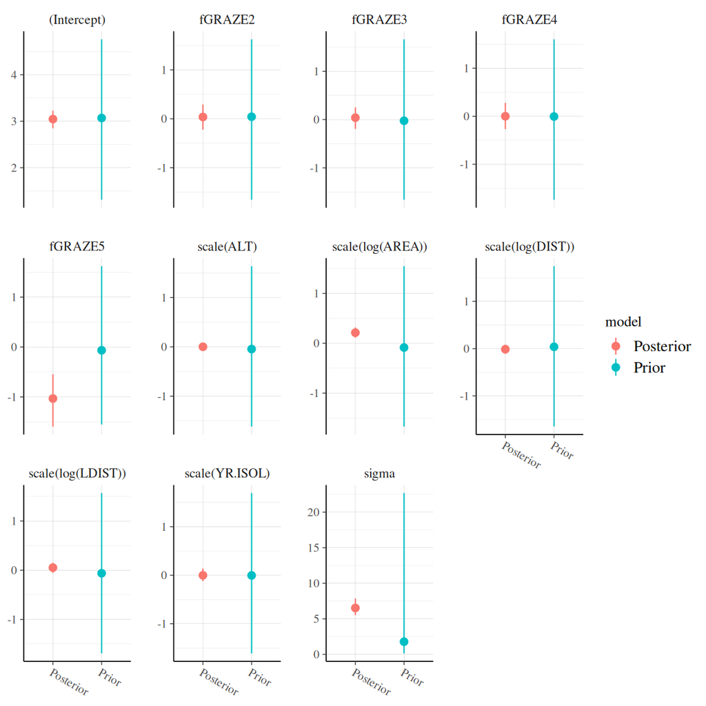

```r
posterior_vs_prior(loyn_rstanarm3,
  color_by = "vs", group_by = TRUE,
  facet_args = list(scales = "free_y")
)
```

**Conclusions:**

- in each case, the prior is substantially wider than the posterior, suggesting that the posterior is not biased towards the prior.

```
Data points may overlap. Use the `jitter` argument to add some amount of
  random variation to the location of data points and avoid overplotting.
```

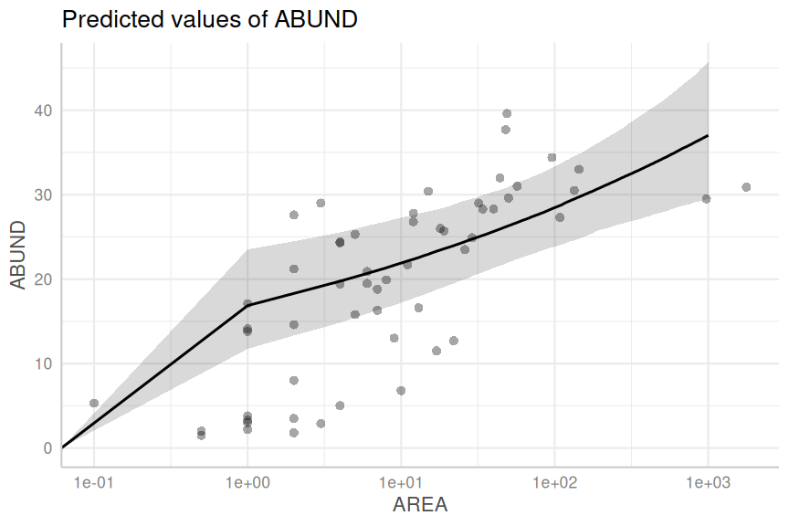

```r
# ggemmeans(loyn_rstanarm3,  ~AREA) |> plot(show_data=TRUE) + scale_y_log10()
ggpredict(loyn_rstanarm3, terms = "AREA[0:1000]") |>
  plot(jitter = FALSE, show_data = TRUE) +
  scale_x_log10() +
  scale_x_log10()
```

[output not shown]

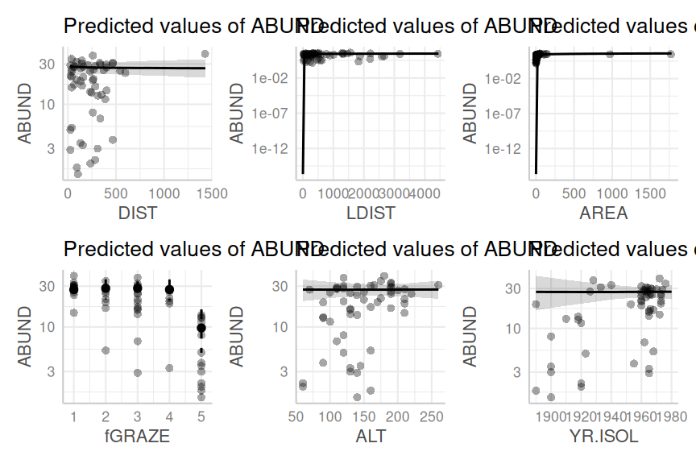

```r
## ggpredict(loyn_rstanarm3,  terms = "AREA[0:1000]") |>
##     plot(jitter = FALSE, residuals=TRUE, log.y = TRUE) + scale_x_log10()
ggpredict(loyn_rstanarm3) |>
  plot(show_data = TRUE) |>
  wrap_plots() &
  scale_y_log10()
```

Note that for the second of the above are partial plots (effect of one predictor at the average of the continuous predictors and the first level of the categorical predictor), the raw data are not similarly standardised and thus may appear not to match the trends…

**brms**

**Using default priors**

In `brms`, the default priors are designed to be weakly informative. They are chosen to provide moderate regularisation (to help prevent over-fitting) and help stabilise the computations.

Unlike `rstanarm`, `brms` models must be compiled before they start sampling. For most models, the compilation of the stan code takes around 45 seconds.

```r
loyn_form <- bf(
  ABUND ~ scale(log(DIST)) +
    scale(log(LDIST)) +
    scale(log(AREA)) +
    fGRAZE +
    scale(ALT) +
    scale(YR.ISOL),
  family = gaussian(link = "log")
)
loyn_brm <- brm(loyn_form,
  data = loyn,
  iter = 5000,
  warmup = 2500,
  chains = 3, cores = 3,
  thin = 5,
  refresh = 0,
  backend = "rstan"
)
```

```r
loyn_brm |> prior_summary()
```

```
                 prior     class          coef group resp dpar nlpar lb ub       source
                (flat)         b                                                default
                (flat)         b       fGRAZE2                             (vectorized)
                (flat)         b       fGRAZE3                             (vectorized)
                (flat)         b       fGRAZE4                             (vectorized)
                (flat)         b       fGRAZE5                             (vectorized)
                (flat)         b      scaleALT                             (vectorized)
                (flat)         b  scalelogAREA                             (vectorized)
                (flat)         b  scalelogDIST                             (vectorized)
                (flat)         b scalelogLDIST                             (vectorized)
                (flat)         b  scaleYR.ISOL                             (vectorized)
  student_t(3, 3, 2.5) Intercept                                                default
 student_t(3, 0, 11.8)     sigma                                      0         default
```

**Assessing priors**

```r
loyn |>
  group_by(fGRAZE) |>
  summarise(
    median(log(ABUND)),
    mad(log(ABUND))
  )
```

```
# A tibble: 5 × 3
  fGRAZE `median(log(ABUND))` `mad(log(ABUND))`
  <fct>                 <dbl>             <dbl>
1 1                      3.38            0.0735
2 2                      3.12            0.280
3 3                      3.04            0.415
4 4                      3.08            0.251
5 5                      1.34            1.10
```

```r
priors <- prior(normal(0, 2.5), class = "b")
loyn_form <- bf(
  ABUND ~ scale(log(DIST)) +
    scale(log(LDIST)) +
    scale(log(AREA)) +
    fGRAZE +
    scale(ALT) +
    scale(YR.ISOL),
  family = gaussian(link = "log")
)
loyn_brm1 <- brm(loyn_form,
  data = loyn,
  prior = priors,
  sample_prior = "only",
  iter = 5000,
  warmup = 2500,
  chains = 3,
  thin = 5,
  refresh = 0,
  backend = "rstan"
)
```

```
Data points may overlap. Use the `jitter` argument to add some amount of
  random variation to the location of data points and avoid overplotting.
```

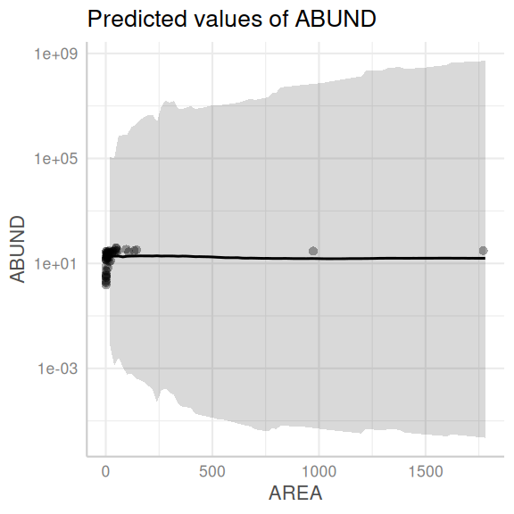

```r
## Individual plots - the following seems to be broken??
## loyn_brm1 |> ggemmeans(~AREA) |> plot(show_data = TRUE) + scale_y_log10()
loyn_brm1 |>
  ggemmeans(~AREA) |>
  plot(show_data = TRUE) + scale_y_log10()
```

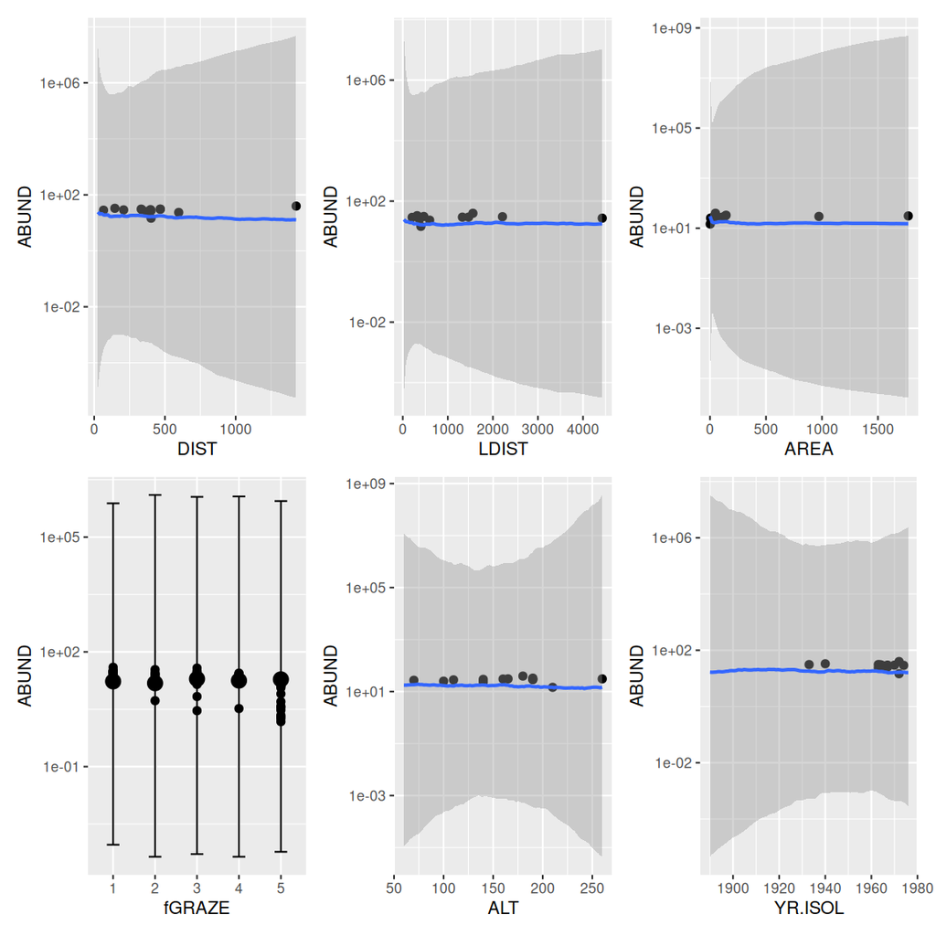

```r
## All effects
loyn_brm1 |>
  conditional_effects() |>
  plot(points = TRUE, ask = FALSE, plot = FALSE) |>
  wrap_plots() &
  scale_y_log10()
```

```
Data points may overlap. Use the `jitter` argument to add some amount of
  random variation to the location of data points and avoid overplotting.
```

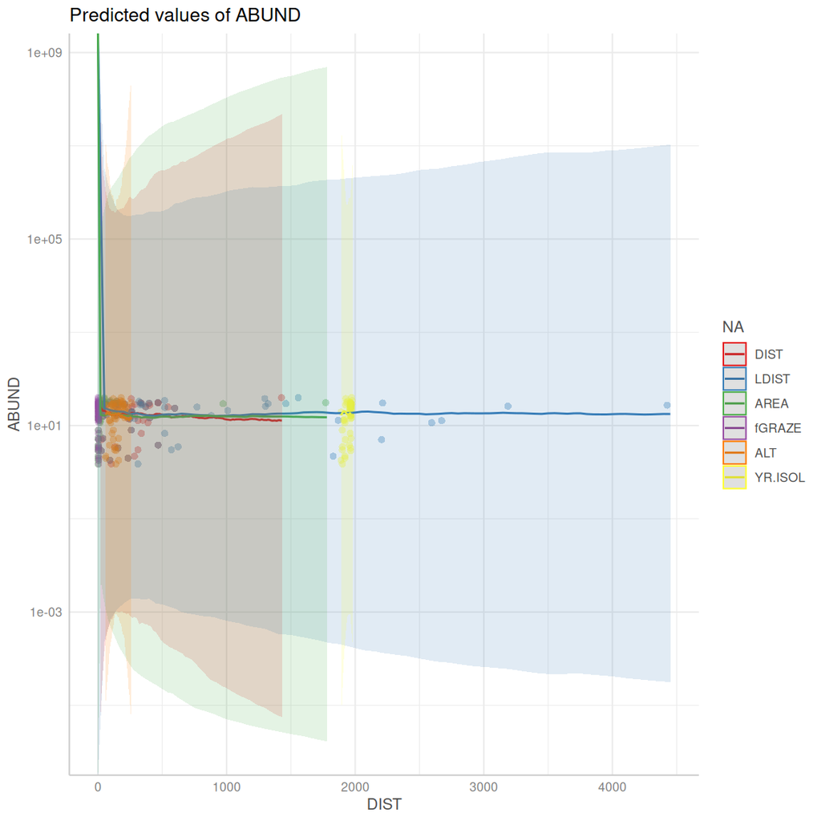

```r
loyn_brm1 |>
  ggpredict() |>
  plot(show_data = TRUE, facet = TRUE) +
  scale_y_log10()
```

**Conclusions:**

**Defining priors**

```r
mod.mat <- model.matrix(as.formula(loyn_form), data = loyn)
mad(log(loyn$ABUND)) /
  apply(mod.mat, 2, mad)
```

```
      (Intercept)  scale(log(DIST)) scale(log(LDIST))  scale(log(AREA))
              Inf         0.6280229         0.5626313         0.5009688
          fGRAZE2           fGRAZE3           fGRAZE4           fGRAZE5
              Inf               Inf               Inf               Inf
       scale(ALT)    scale(YR.ISOL)
        0.5127373         1.3907494
```

```r
loyn |>
  group_by(fGRAZE) |>
  summarise(
    median = median(log(ABUND)),
    mad = mad(log(ABUND))
  )
```

```
# A tibble: 5 × 3
  fGRAZE median    mad
  <fct>   <dbl>  <dbl>
1 1        3.38 0.0735
2 2        3.12 0.280
3 3        3.04 0.415
4 4        3.08 0.251
5 5        1.34 1.10
```

```r
priors <- prior(normal(3.4, 0.1), class = "Intercept") +
  prior(normal(0, 2), class = "b") +
  prior(student_t(3, 0, 1.5), class = "sigma")
loyn_form <- bf(
  ABUND ~ scale(log(DIST)) +
    scale(log(LDIST)) +
    scale(log(AREA)) +
    fGRAZE +
    scale(ALT) +
    scale(YR.ISOL),
  family = gaussian(link = "log")
)
loyn_brm2 <- brm(loyn_form,
  data = loyn,
  prior = priors,
  sample_prior = "only",
  iter = 5000,
  warmup = 2500,
  chains = 3, cores = 3,
  thin = 5,
  refresh = 0,
  backend = "rstan"
)
```

```
Data points may overlap. Use the `jitter` argument to add some amount of
  random variation to the location of data points and avoid overplotting.
```

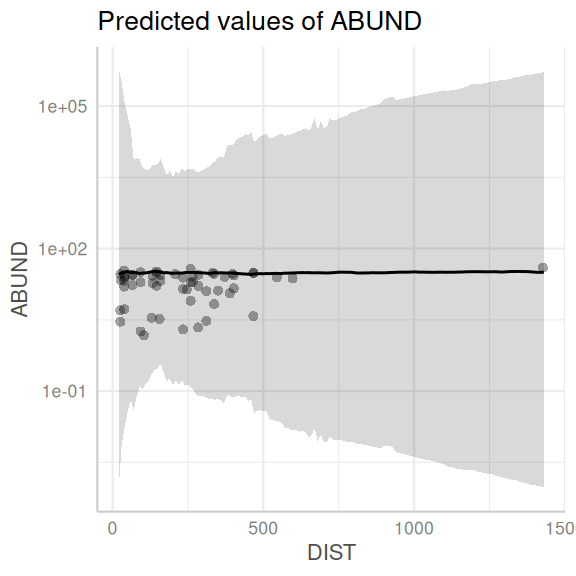

```r
loyn_brm2 |>
  ggemmeans(~DIST) |>
  plot(show_data = TRUE) +
  scale_y_log10()
```

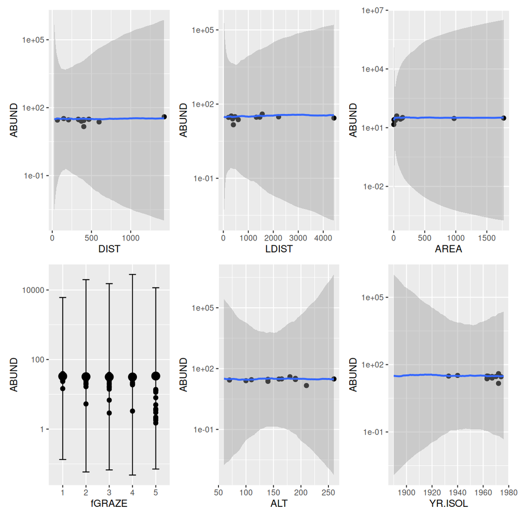

```r
loyn_brm2 |>
  conditional_effects() |>
  plot(points = TRUE, ask = FALSE, plot = FALSE) |>
  ## lapply(function(x) x + scale_y_log10()) |>
  wrap_plots() &
  scale_y_log10()
```

```
Data points may overlap. Use the `jitter` argument to add some amount of
  random variation to the location of data points and avoid overplotting.
```

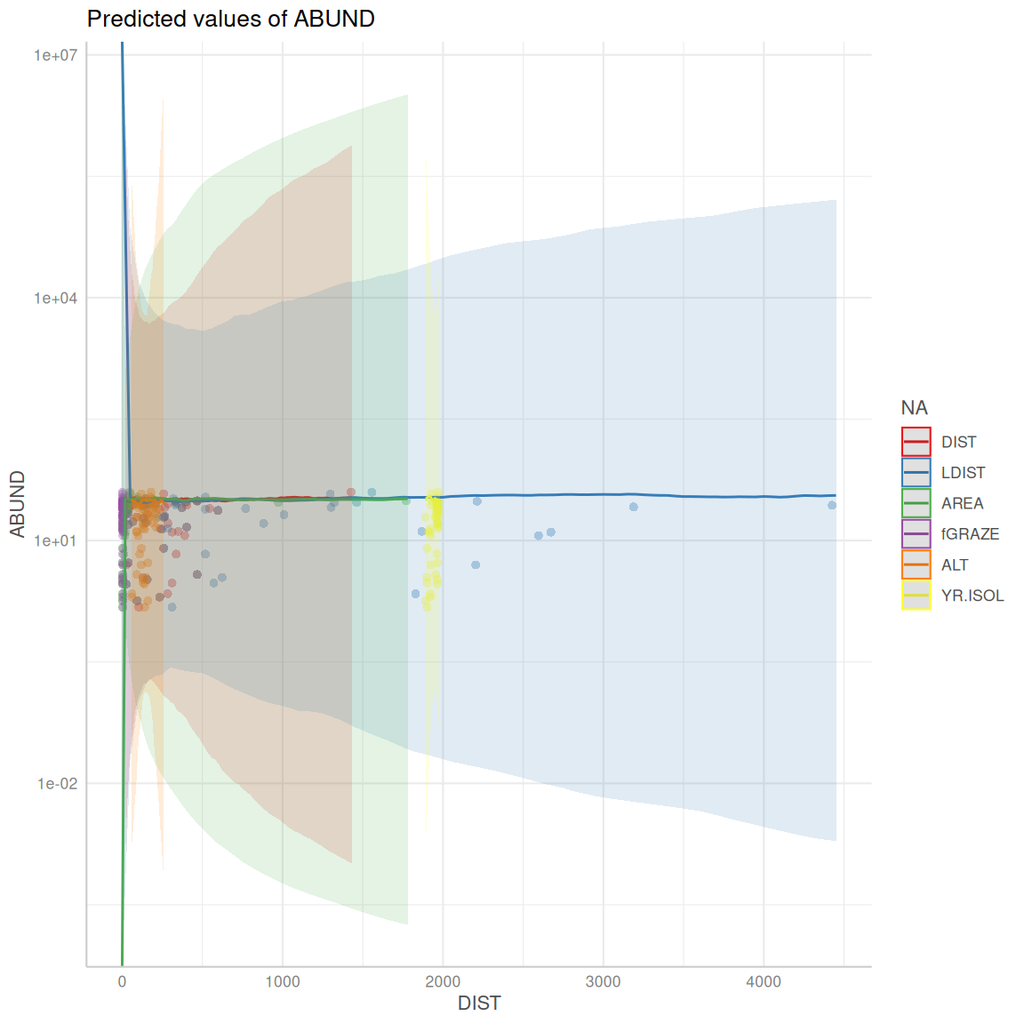

```r
loyn_brm2 |>
  ggpredict() |>
  plot(show_data = TRUE, facet = TRUE) +
  scale_y_log10()
```

```r
loyn_brm3 <- update(loyn_brm2, sample_prior = "yes", refresh = 0)
```

```
The desired updates require recompiling the model
```

**Plotting prior and posterior**

```r
loyn_brm3 |> get_variables()
```

```
 [1] "b_Intercept"     "b_scalelogDIST"  "b_scalelogLDIST" "b_scalelogAREA"
 [5] "b_fGRAZE2"       "b_fGRAZE3"       "b_fGRAZE4"       "b_fGRAZE5"
 [9] "b_scaleALT"      "b_scaleYR.ISOL"  "sigma"           "Intercept"
[13] "prior_Intercept" "prior_b"         "prior_sigma"     "lprior"
[17] "lp__"            "accept_stat__"   "stepsize__"      "treedepth__"
[21] "n_leapfrog__"    "divergent__"     "energy__"
```

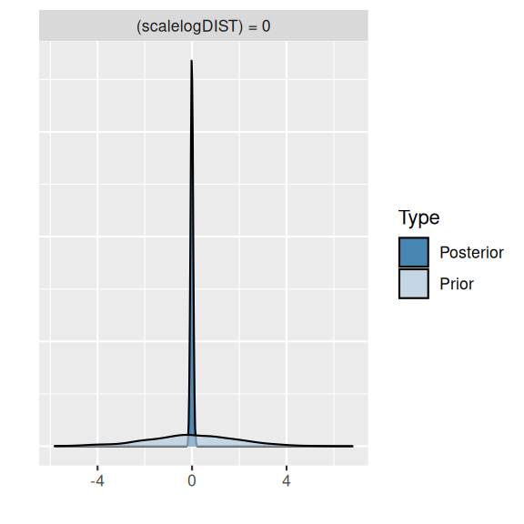

```r
## loyn_brm3 |> hypothesis('Intercept = 0', class = 'b') |> plot
## loyn_brm3 |> hypothesis('Intercept = 0', class = 'prior') |> plot
loyn_brm3 |>
  hypothesis("scalelogDIST = 0") |>
  plot()
```

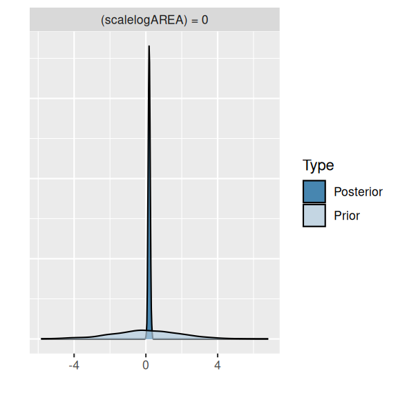

```r
loyn_brm3 |>
  hypothesis("scalelogAREA = 0") |>
  plot()
```

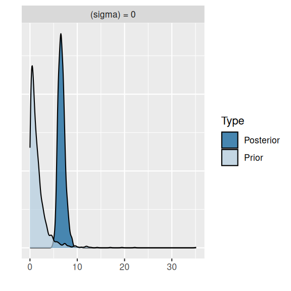

```r
loyn_brm3 |>
  hypothesis("sigma = 0", class = "") |>
  plot()
```

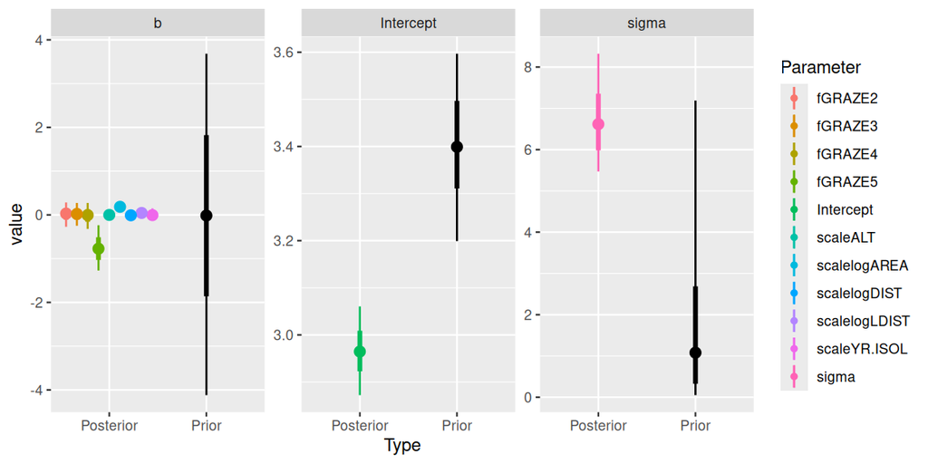

```r
loyn_brm3 |> SUYR_prior_and_posterior()
```

**Exploring the stan code**

```r
loyn_brm3 |> standata()
```

```
$N
[1] 56

$Y
 [1]  5.3  2.0  1.5 17.1 13.8 14.1  3.8  2.2  3.3  3.0 27.6  1.8 21.2 14.6  8.0
[16]  3.5 29.0  2.9 24.3 19.4 24.4  5.0 15.8 25.3 19.5 20.9 16.3 18.8 19.9 13.0
[31]  6.8 21.7 27.8 26.8 16.6 30.4 11.5 26.0 25.7 12.7 23.5 24.9 29.0 28.3 28.3
[46] 32.0 37.7 39.6 29.6 31.0 34.4 27.3 30.5 33.0 29.5 30.9

$K
[1] 10

$Kc
[1] 9

```

[output cut: 132 more lines]

```r
loyn_brm3 |> stancode()
```

```
// generated with brms 2.22.0
functions {
}
data {
  int<lower=1> N;  // total number of observations
  vector[N] Y;  // response variable
  int<lower=1> K;  // number of population-level effects
  matrix[N, K] X;  // population-level design matrix
  int<lower=1> Kc;  // number of population-level effects after centering
  int prior_only;  // should the likelihood be ignored?
}
transformed data {
  matrix[N, Kc] Xc;  // centered version of X without an intercept
  vector[Kc] means_X;  // column means of X before centering
  for (i in 2:K) {
    means_X[i - 1] = mean(X[, i]);
    Xc[, i - 1] = X[, i] - means_X[i - 1];
  }
}
parameters {
  vector[Kc] b;  // regression coefficients
  real Intercept;  // temporary intercept for centered predictors
  real<lower=0> sigma;  // dispersion parameter
}
transformed parameters {
  real lprior = 0;  // prior contributions to the log posterior
  lprior += normal_lpdf(b | 0, 2);
  lprior += normal_lpdf(Intercept | 3.4, 0.1);
  lprior += student_t_lpdf(sigma | 3, 0, 1.5)
    - 1 * student_t_lccdf(0 | 3, 0, 1.5);
}
model {
  // likelihood including constants
  if (!prior_only) {
    // initialize linear predictor term
    vector[N] mu = rep_vector(0.0, N);
    mu += Intercept + Xc * b;
    mu = exp(mu);
    target += normal_lpdf(Y | mu, sigma);
  }
  // priors including constants
  target += lprior;
}
generated quantities {
  // actual population-level intercept
  real b_Intercept = Intercept - dot_product(means_X, b);
  // additionally sample draws from priors
  real prior_b = normal_rng(0,2);
  real prior_Intercept = normal_rng(3.4,0.1);
  real prior_sigma = student_t_rng(3,0,1.5);
  // use rejection sampling for truncated priors
  while (prior_sigma < 0) {
    prior_sigma = student_t_rng(3,0,1.5);
  }
}
```

# 6 MCMC sampling diagnostics

**rstanarm**

**bayesplot**

The `bayesplot` package offers a range of MCMC diagnostics as well as Posterior Probability Checks (PPC), all of which have a convenient `plot()` interface. Lets start with the MCMC diagnostics.

**See list of available diagnostics by name**

```r
available_mcmc()
```

```
bayesplot MCMC module:
  mcmc_acf
  mcmc_acf_bar
  mcmc_areas
  mcmc_areas_ridges
  mcmc_combo
  mcmc_dens
  mcmc_dens_chains
  mcmc_dens_overlay
  mcmc_hex
  mcmc_hist
  mcmc_hist_by_chain
  mcmc_intervals
  mcmc_neff
  mcmc_neff_hist
  mcmc_nuts_acceptance
  mcmc_nuts_divergence
  mcmc_nuts_energy
  mcmc_nuts_stepsize
  mcmc_nuts_treedepth
  mcmc_pairs
  mcmc_parcoord
  mcmc_rank_ecdf
  mcmc_rank_hist
  mcmc_rank_overlay
  mcmc_recover_hist
  mcmc_recover_intervals
  mcmc_recover_scatter
  mcmc_rhat
  mcmc_rhat_hist
  mcmc_scatter
  mcmc_trace
  mcmc_trace_highlight
  mcmc_violin
```

Of these, we will focus on:

- mcmc_trace: this plots the estimates of each parameter over the post-warmup length of each MCMC chain. Each chain is plotted in a different shade of blue, with each parameter in its own facet. Ideally, each **trace** should just look like noise without any discernible drift and each of the traces for a specific parameter should look the same (i.e, should not be displaced above or below any other trace for that parameter).

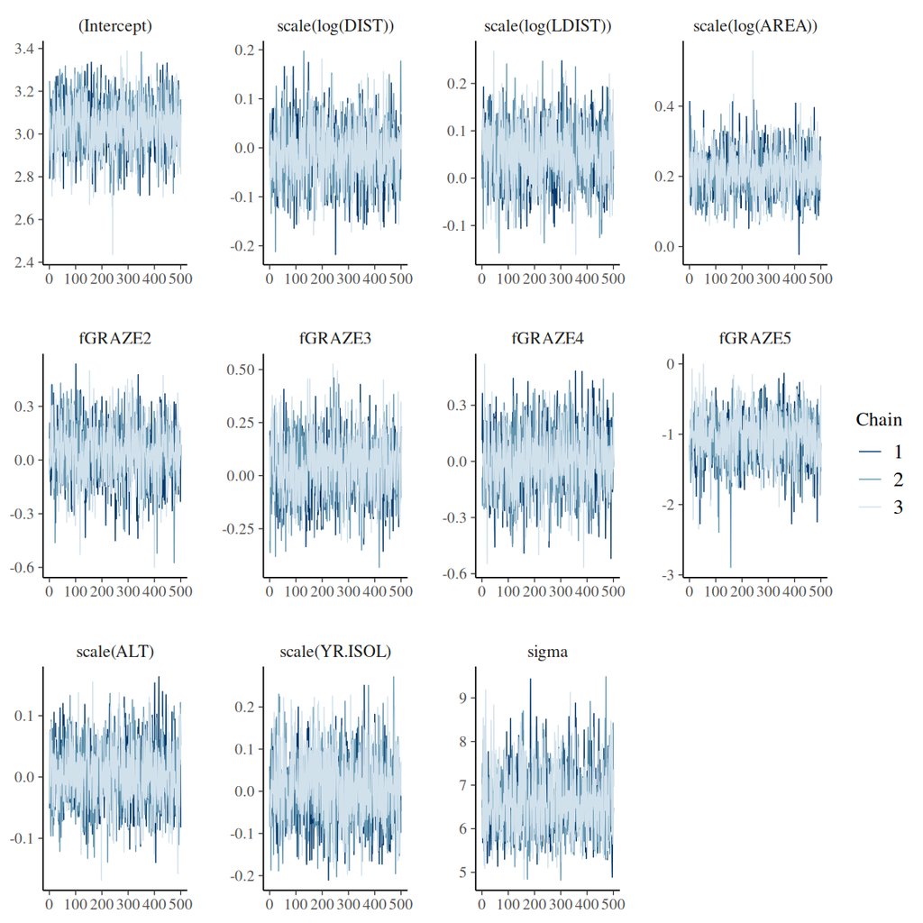

```r
plot(loyn_rstanarm3, plotfun = "mcmc_trace")
```

The chains appear well mixed and very similar

- acf (auto-correlation function): plots the auto-correlation between successive MCMC sample lags for each parameter and each chain

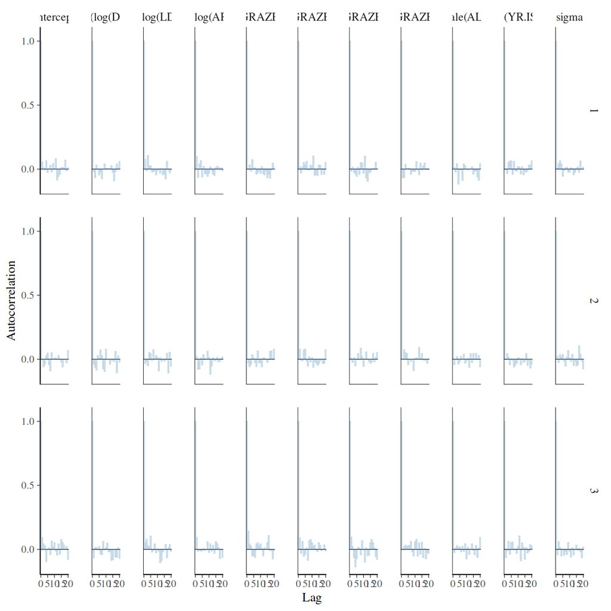

```r
plot(loyn_rstanarm3, "acf_bar")
```

There is no evidence of auto-correlation in the MCMC samples

- Rhat: Rhat is a measure of convergence between the chains. The closer the values are to 1, the more the chains have converged. Values greater than 1.05 indicate a lack of convergence. There will be an Rhat value for each parameter estimated.

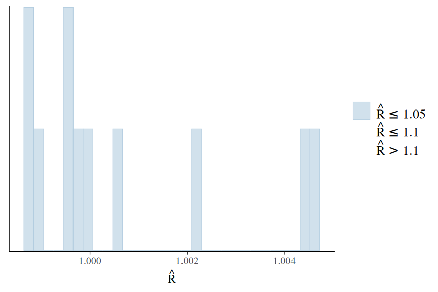

```r
plot(loyn_rstanarm3, "rhat_hist")
```

All Rhat values are below 1.05, suggesting the chains have converged.